# Excercise Quality Prediction

Zoltan Novak

Sunday, May 19, 2015

# Purpose of Analysis

The following study focuses on analyzing data captured from wearable personal devices like Jawbone Up, Nike FuelBand, and Fitbit (for more information in data please refer to Appendix 1) during excercising.  
The purpose of the study is to create a prediction model on the provided data, predicting the manner the user did the specific excercise (“classe”) knowing the other variables in the data set.

# Input Data

I am downloading the training and testing CSV files (if not downloaded yet) and loading those into data frames. Training data will be used to build and validate my prediction, while test data is used to submit my results for grading.

```r
#Downloading the training data set data if does not exist
if (!file.exists("pml-training.csv")){
        download.file(url = "https://d396qusza40orc.cloudfront.net/predmachlearn/pml-training.csv",
                      destfile="pml-training.csv",
                      method="auto",
                      quiet = FALSE,
                      mode = "wb")
}

#Downloading the testing data set data if does not exist
if (!file.exists("pml-testing.csv")){
        download.file(url = "https://d396qusza40orc.cloudfront.net/predmachlearn/pml-testing.csv",
                      destfile="pml-testing.csv",
                      method="auto",
                      quiet = FALSE,
                      mode = "wb")
}

train.Raw <- read.csv("pml-training.csv", header=T)
test.Raw<- read.csv("pml-testing.csv", header=T)
```

# Features

There is limited knowledge available on the variables still for the sake of performance and avoiding overfitting, I will remove variables which are obviously irrelevant ones like 1) where count of NA values > 50%, 2) metadata, ID, timestamp variables, 3) variables with near zero variance and 4) variables that are highly correlating with each other. My first attempts to train my Machine Learning model with Decision Tree and Random Forest methods failed when I did not remove variables with correlation. Model train run time was couple of hours before I terminated. Hence I decided to continue the analysis with 2 scenarios: removing variables above 0.5 correlation and in case prediction accuracy is not sufficient then train the model removing variables only above 0.7 correlation.

```r
library(caret)
# get column indicies where the count of NA values is less than 50%
colScope.1 <- which(apply(train.Raw, 2, function(x) {(length(which(!is.na(x))) / (length(x))) > 0.5}), arr.ind=T, useNames=F)
# remove ID (1) and timestamp & metadata columns (3, 4, 5, 6, 7)
colScope.2 <- colScope.1[-c(1, 2, 3, 4, 5, 6, 7)]
train.Raw2 <- train.Raw[, colScope.2]
# remove variables with near zero variances
nzvIdx <- nzv(train.Raw2)
train.Raw2 <- train.Raw2[, -nzvIdx]
# OPTION A: remove corelating variables (0.5 is the treshold)
corIdx.LOW <- findCorrelation(cor(train.Raw2[, -c(53)]), cutoff = 0.5)
# OPTION B: remove corelating variables (0.7 is the treshold)
corIdx.MED <- findCorrelation(cor(train.Raw2[, -c(53)]), cutoff = 0.7)

train.Raw.Low.Cor <- train.Raw2[, -corIdx.LOW]
train.Raw.Med.Cor <- train.Raw2[, -corIdx.MED]


# applying the same transformations on the PROJECT QUIZ TEST dataset
quiz.test.data <- test.Raw[, colScope.2]
quiz.test.data <- quiz.test.data[, -nzvIdx]
quiz.test.data <- quiz.test.data[, -corIdx.MED]
```

```r
colnames(train.Raw.Low.Cor)
```

```
##  [1] "gyros_belt_x"        "gyros_belt_y"        "gyros_belt_z"
##  [4] "magnet_belt_z"       "roll_arm"            "pitch_arm"
##  [7] "yaw_arm"             "total_accel_arm"     "gyros_arm_x"
## [10] "gyros_arm_z"         "roll_dumbbell"       "pitch_dumbbell"
## [13] "gyros_dumbbell_z"    "roll_forearm"        "pitch_forearm"
## [16] "yaw_forearm"         "total_accel_forearm" "gyros_forearm_x"
## [19] "accel_forearm_z"     "magnet_forearm_x"    "magnet_forearm_y"
## [22] "classe"
```

```r
colnames(train.Raw.Med.Cor)
```

```
##  [1] "gyros_belt_x"         "gyros_belt_y"         "gyros_belt_z"
##  [4] "magnet_belt_x"        "magnet_belt_z"        "roll_arm"
##  [7] "pitch_arm"            "yaw_arm"              "total_accel_arm"
## [10] "gyros_arm_x"          "gyros_arm_z"          "magnet_arm_x"
## [13] "magnet_arm_z"         "roll_dumbbell"        "pitch_dumbbell"
## [16] "yaw_dumbbell"         "total_accel_dumbbell" "gyros_dumbbell_y"
## [19] "gyros_dumbbell_z"     "magnet_dumbbell_z"    "roll_forearm"
## [22] "pitch_forearm"        "yaw_forearm"          "total_accel_forearm"
## [25] "gyros_forearm_x"      "accel_forearm_x"      "accel_forearm_z"
## [28] "magnet_forearm_x"     "magnet_forearm_y"     "magnet_forearm_z"
## [31] "classe"
```

# Algorithm

I will partition the available data into training and testing data sets with a split of 60-40 as suggested in the lectures. I have chosen to implement Machine Learning for prediction using first Classification Tree and second Random Forest. I expect that Decision Tree will provide faster but less accurate results while Random Forest will be significantly slower however more accurate as well. I will create models using 2 different set of predictors as highlighted in the Features paragraph.

```r
library(rpart)
library(randomForest)
library(rattle)

# create training, testing and validation data sets
set.seed(1980)
inTrain.Low <- createDataPartition(y=train.Raw.Low.Cor$classe, p=0.6, list=F)
inTrain.Med <- createDataPartition(y=train.Raw.Med.Cor$classe, p=0.6, list=F)

#data sets where I removed variables with correlation > 0.5
train.data.Low <- train.Raw.Low.Cor[inTrain.Low, ]
test.data.Low  <- train.Raw.Low.Cor[-inTrain.Low, ]

#data sets where I removed variables with correlation > 0.7
train.data.Med <- train.Raw.Med.Cor[inTrain.Med, ]
test.data.Med  <- train.Raw.Med.Cor[-inTrain.Med, ]

#building & training the prediction models with the 2 sets of predictors, using RPART and RT methods
model.RPART.Low <- train(train.data.Low$classe ~ ., data = train.data.Low, method="rpart")
model.RPART.Med <- train(train.data.Med$classe ~ ., data = train.data.Med, method="rpart")
model.RFORE.Low <- train(train.data.Low$classe ~ ., data = train.data.Low, method="rf")
model.RFORE.Med <- train(train.data.Med$classe ~ ., data = train.data.Med, method="rf")

#prediction on the test data sets
pred.RPART.Low <- predict(model.RPART.Low, newdata=test.data.Low)
pred.RPART.Med <- predict(model.RPART.Med, newdata=test.data.Med)
pred.RFOREST.Low <- predict(model.RFORE.Low, newdata=test.data.Low)
pred.RFOREST.Med <- predict(model.RFORE.Med, newdata=test.data.Med)

#confusion matrices for later assessment
cm.RPART.Low <- confusionMatrix(pred.RPART.Low, test.data.Low$classe)
cm.RPART.Med <- confusionMatrix(pred.RPART.Med, test.data.Med$classe)
cm.RFOREST.Low <- confusionMatrix(pred.RFOREST.Low, test.data.Low$classe)
cm.RFOREST.Med <- confusionMatrix(pred.RFOREST.Med, test.data.Med$classe)
```

# Parameters & Evaluation

After running the model trainings with Classification Tree and Random Forest methods (default ‘out-of-the-box’ parameters), I reviewed the confusion matricies the 2 different set of descriptor variables the concluded the following:

```r
cm.RPART.Low
```

```
## Confusion Matrix and Statistics
##
##           Reference
## Prediction    A    B    C    D    E
##          A 1772  427  352  284  228
##          B  239  641  119  528  345
##          C  219  430  893  307  314
##          D    0    0    0    0    0
##          E    2   20    4  167  555
##
## Overall Statistics
##
##                Accuracy : 0.4921
##                  95% CI : (0.481, 0.5032)
##     No Information Rate : 0.2845
##     P-Value [Acc > NIR] : < 2.2e-16
##
##                   Kappa : 0.3465
##  Mcnemar's Test P-Value : < 2.2e-16
##
## Statistics by Class:
##
##                      Class: A Class: B Class: C Class: D Class: E
## Sensitivity            0.7939   0.4223   0.6528   0.0000  0.38488
## Specificity            0.7700   0.8055   0.8040   1.0000  0.96986
## Pos Pred Value         0.5785   0.3424   0.4129      NaN  0.74198
## Neg Pred Value         0.9038   0.8532   0.9164   0.8361  0.87504
## Prevalence             0.2845   0.1935   0.1744   0.1639  0.18379
## Detection Rate         0.2258   0.0817   0.1138   0.0000  0.07074
## Detection Prevalence   0.3904   0.2386   0.2757   0.0000  0.09534
## Balanced Accuracy      0.7820   0.6139   0.7284   0.5000  0.67737
```

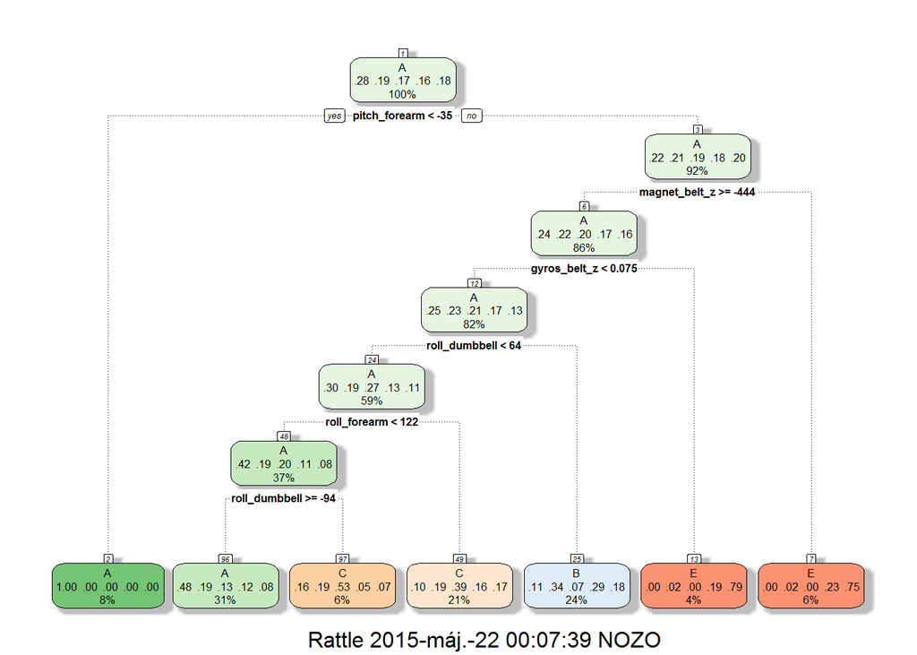

```r
fancyRpartPlot(model.RPART.Low$finalModel)
```

```r
cm.RPART.Med
```

```
## Confusion Matrix and Statistics
##
##           Reference
## Prediction    A    B    C    D    E
##          A 1756  468  513  350  230
##          B   34  549   58  157  246
##          C   43  193  615  295  188
##          D   85   52    1  324   39
##          E  314  256  181  160  739
##
## Overall Statistics
##
##                Accuracy : 0.5076
##                  95% CI : (0.4965, 0.5188)
##     No Information Rate : 0.2845
##     P-Value [Acc > NIR] : < 2.2e-16
##
##                   Kappa : 0.3649
##  Mcnemar's Test P-Value : < 2.2e-16
##
## Statistics by Class:
##
##                      Class: A Class: B Class: C Class: D Class: E
## Sensitivity            0.7867  0.36166  0.44956  0.25194  0.51248
## Specificity            0.7219  0.92178  0.88901  0.97302  0.85775
## Pos Pred Value         0.5294  0.52586  0.46102  0.64671  0.44788
## Neg Pred Value         0.8949  0.85754  0.88437  0.86903  0.88654
## Prevalence             0.2845  0.19347  0.17436  0.16391  0.18379
## Detection Rate         0.2238  0.06997  0.07838  0.04129  0.09419
## Detection Prevalence   0.4228  0.13306  0.17002  0.06385  0.21030
## Balanced Accuracy      0.7543  0.64172  0.66929  0.61248  0.68511
```

[figure not shown]

```r
fancyRpartPlot(model.RPART.Med$finalModel)
```

```r
cm.RFOREST.Low
```

```
## Confusion Matrix and Statistics
##
##           Reference
## Prediction    A    B    C    D    E
##          A 2221   25    2    1    1
##          B    9 1470   18    0    0
##          C    1   18 1340   44    2
##          D    1    5    6 1233    4
##          E    0    0    2    8 1435
##
## Overall Statistics
##
##                Accuracy : 0.9813
##                  95% CI : (0.978, 0.9841)
##     No Information Rate : 0.2845
##     P-Value [Acc > NIR] : < 2.2e-16
##
##                   Kappa : 0.9763
##  Mcnemar's Test P-Value : NA
##
## Statistics by Class:
##
##                      Class: A Class: B Class: C Class: D Class: E
## Sensitivity            0.9951   0.9684   0.9795   0.9588   0.9951
## Specificity            0.9948   0.9957   0.9900   0.9976   0.9984
## Pos Pred Value         0.9871   0.9820   0.9537   0.9872   0.9931
## Neg Pred Value         0.9980   0.9924   0.9957   0.9920   0.9989
## Prevalence             0.2845   0.1935   0.1744   0.1639   0.1838
## Detection Rate         0.2831   0.1874   0.1708   0.1572   0.1829
## Detection Prevalence   0.2868   0.1908   0.1791   0.1592   0.1842
## Balanced Accuracy      0.9950   0.9821   0.9847   0.9782   0.9968
```

```r
cm.RFOREST.Med
```

```
## Confusion Matrix and Statistics
##
##           Reference
## Prediction    A    B    C    D    E
##          A 2224   16    1    0    0
##          B    8 1492   16    0    1
##          C    0   10 1341   34    0
##          D    0    0   10 1252    4
##          E    0    0    0    0 1437
##
## Overall Statistics
##
##                Accuracy : 0.9873
##                  95% CI : (0.9845, 0.9896)
##     No Information Rate : 0.2845
##     P-Value [Acc > NIR] : < 2.2e-16
##
##                   Kappa : 0.9839
##  Mcnemar's Test P-Value : NA
##
## Statistics by Class:
##
##                      Class: A Class: B Class: C Class: D Class: E
## Sensitivity            0.9964   0.9829   0.9803   0.9736   0.9965
## Specificity            0.9970   0.9960   0.9932   0.9979   1.0000
## Pos Pred Value         0.9924   0.9835   0.9682   0.9889   1.0000
## Neg Pred Value         0.9986   0.9959   0.9958   0.9948   0.9992
## Prevalence             0.2845   0.1935   0.1744   0.1639   0.1838
## Detection Rate         0.2835   0.1902   0.1709   0.1596   0.1832
## Detection Prevalence   0.2856   0.1933   0.1765   0.1614   0.1832
## Balanced Accuracy      0.9967   0.9895   0.9867   0.9857   0.9983
```

```r
sum(pred.RFOREST.Med != test.data.Med$classe)/length(test.data.Med$classe)
```

```
## [1] 0.01274535
```

# Conclusion

I am using Random Forest (with extended set of predictors) since that has provided the most accurate prediction (greater than 98% even with the smallest set of predictors). Prediction results are:

```r
prediction.quiz <- predict(model.RFORE.Med, newdata=quiz.test.data)
print(prediction.quiz)
```

```
##  [1] B A B A A E D B A A B C B A E E A B B B
## Levels: A B C D E
```

# Generating Files for Coursera Project Grading

I am using the script provided at the Coursera website.

```r
pml_write_files = function(x){
  n = length(x)
  for(i in 1:n){
    filename = paste0("problem_id_",i,".txt")
    write.table(x[i],file=filename,quote=FALSE,row.names=FALSE,col.names=FALSE)
  }
}

pml_write_files(prediction.quiz)
```

# **Appendix 1 - Data Sources**

The training data for this project are available here: https://d396qusza40orc.cloudfront.net/predmachlearn/pml-training.csv  
The test data are available here: https://d396qusza40orc.cloudfront.net/predmachlearn/pml-testing.csv  
The data for this project come from this source: http://groupware.les.inf.puc-rio.br/har